# MachineLearningModelsforWeatherPrediction

Installing Dependencies

```python
import time
import numpy as np
import tensorflow as tf
from sklearn.metrics import mean_squared_error, mean_absolute_error, r2_score
import matplotlib.pyplot as plt
import psutil
import pandas as pd
from sklearn.preprocessing import MinMaxScaler, StandardScaler
from sklearn.model_selection import train_test_split
from sklearn.svm import SVR
from xgboost import XGBRegressor
from statsmodels.tsa.arima.model import ARIMA
from tensorflow.keras.models import Sequential
from tensorflow.keras.layers import LSTM, GRU, Bidirectional, Dense, Conv1D, Flatten, Input, SimpleRNN, Attention
from tensorflow.keras.models import Model
```

Data Preprocessing, Data Cleaning and EDA

```python
# Initialize performance metrics
process = psutil.Process()
start_time = time.time()
initial_cpu_percent = process.cpu_percent(interval=None)
initial_memory_usage = process.memory_info().rss / 1024 / 1024  # Memory in MB

# Load and preprocess data
data = pd.read_csv('temphumid data.csv', header=None, names=['Date', 'Time', 'Temp', 'Humidity'])

# Check for missing values and handle them
print("Initial data shape:", data.shape)
print("Missing values per column:")
print(data.isnull().sum())

# Handle missing values
data = data.dropna()

# Check if data contains duplicate rows
print("Duplicate rows in the dataset:", data.duplicated().sum())
data = data.drop_duplicates()

# Extract temperature and humidity values
data['Temperature'] = data['Temp'].str.extract(r'T=(\d+\.\d+)').astype(float)
data['Humidity'] = data['Humidity'].str.extract(r'H=(\d+\.\d+)').astype(float)

# Check data types
print("Data types of columns:")
print(data.dtypes)

# Check for outliers in Temperature and Humidity
print("Temperature statistics:")
print(data['Temperature'].describe())
print("Humidity statistics:")
print(data['Humidity'].describe())
```

```
Initial data shape: (336, 4)
Missing values per column:
Date         0
Time         0
Temp         0
Humidity    16
dtype: int64
Duplicate rows in the dataset: 0
Data types of columns:
Date            object
Time            object
Temp            object
Humidity       float64
Temperature    float64
dtype: object
Temperature statistics:
count    320.000000
mean      21.353125
std        5.047454
min        9.000000
25%       18.000000
50%       20.000000
75%       23.000000
max       37.000000
Name: Temperature, dtype: float64
Humidity statistics:
count    320.000000
mean      21.865625
std        7.625486
min       12.000000
25%       20.000000
50%       21.000000
75%       23.250000
max      140.000000
Name: Humidity, dtype: float64
```

EDA and Data Completion Checks

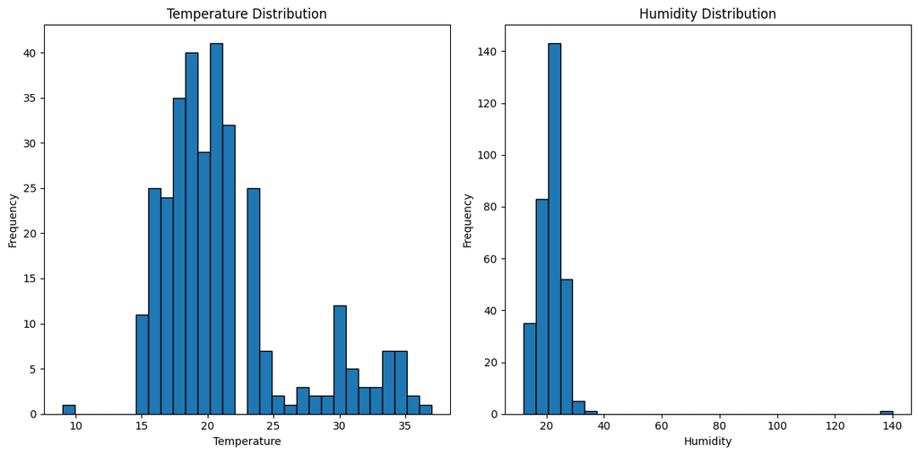

```
Missing DateTime values: 0
```

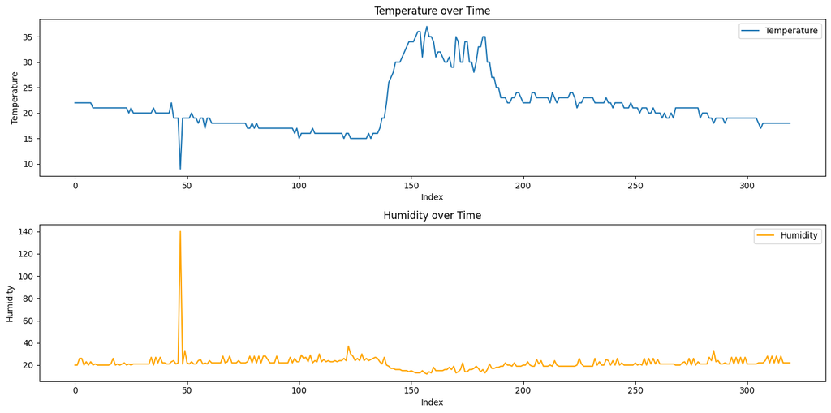

```python
# Plot histograms of Temperature and Humidity
plt.figure(figsize=(12, 6))
plt.subplot(1, 2, 1)
plt.hist(data['Temperature'], bins=30, edgecolor='k')
plt.title('Temperature Distribution')
plt.xlabel('Temperature')
plt.ylabel('Frequency')

plt.subplot(1, 2, 2)
plt.hist(data['Humidity'], bins=30, edgecolor='k')
plt.title('Humidity Distribution')
plt.xlabel('Humidity')
plt.ylabel('Frequency')

plt.tight_layout()
plt.show()

# Check for data consistency
data['DateTime'] = pd.to_datetime(data['Date'] + ' ' + data['Time'], errors='coerce')
print("Missing DateTime values:", data['DateTime'].isnull().sum())
data = data.dropna(subset=['DateTime'])

data['Year'] = data['DateTime'].dt.year
data['Month'] = data['DateTime'].dt.month
data['Day'] = data['DateTime'].dt.day
data['Hour'] = data['DateTime'].dt.hour
data['Minute'] = data['DateTime'].dt.minute
data = data[['Year', 'Month', 'Day', 'Hour', 'Minute', 'Temperature', 'Humidity']]


# Plot time series of Temperature and Humidity
plt.figure(figsize=(14, 7))
plt.subplot(2, 1, 1)
#plt.plot(data['DateTime'], data['Temperature'], label='Temperature') #The DateTime column does not exist anymore. Replace with a suitable x-axis variable or a range of values.
plt.plot(range(len(data['Temperature'])), data['Temperature'], label='Temperature') # In this case, using the index as x-axis
plt.title('Temperature over Time')
plt.xlabel('Index') # Changed from 'DateTime' to 'Index'
plt.ylabel('Temperature')
plt.legend()

plt.subplot(2, 1, 2)
#plt.plot(data['DateTime'], data['Humidity'], label='Humidity', color='orange') #The DateTime column does not exist anymore. Replace with a suitable x-axis variable or a range of values.
plt.plot(range(len(data['Humidity'])), data['Humidity'], label='Humidity', color='orange') # In this case, using the index as x-axis
plt.title('Humidity over Time')
plt.xlabel('Index') # Changed from 'DateTime' to 'Index'
plt.ylabel('Humidity')
plt.legend()

plt.tight_layout()
plt.show()
```

Comparison of Different ML Techniques

```
Shape of X_test: (44, 100, 7)
```

[output not shown]

[output cut: 145 more lines]

[output not shown]

[output not shown]

[output cut: 45 more lines]

[output not shown]

[output not shown]

[output cut: 145 more lines]

[output not shown]

[output not shown]

[output cut: 213 more lines]

```
Humidity MSE: 0.0008, RMSE: 0.0288, MAE: 0.0236, R2 Score: -0.0528
2/2 ━━━━━━━━━━━━━━━━━━━━ 0s 14ms/step
2/2 ━━━━━━━━━━━━━━━━━━━━ 0s 15ms/step
2/2 ━━━━━━━━━━━━━━━━━━━━ 0s 18ms/step
2/2 ━━━━━━━━━━━━━━━━━━━━ 0s 6ms/step
2/2 ━━━━━━━━━━━━━━━━━━━━ 0s 7ms/step
2/2 ━━━━━━━━━━━━━━━━━━━━ 0s 4ms/step
2/2 ━━━━━━━━━━━━━━━━━━━━ 0s 11ms/step
2/2 ━━━━━━━━━━━━━━━━━━━━ 0s 16ms/step
2/2 ━━━━━━━━━━━━━━━━━━━━ 0s 19ms/step
2/2 ━━━━━━━━━━━━━━━━━━━━ 0s 18ms/step
2/2 ━━━━━━━━━━━━━━━━━━━━ 0s 5ms/step
2/2 ━━━━━━━━━━━━━━━━━━━━ 0s 7ms/step
2/2 ━━━━━━━━━━━━━━━━━━━━ 0s 5ms/step
2/2 ━━━━━━━━━━━━━━━━━━━━ 0s 12ms/step
```

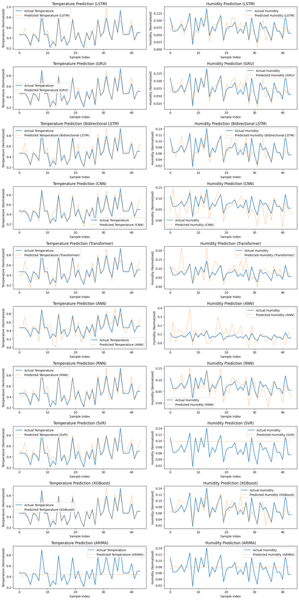

```python
# Normalize features
scaler = MinMaxScaler()
data[['Temperature', 'Humidity']] = scaler.fit_transform(data[['Temperature', 'Humidity']])
data[['Year', 'Month', 'Day', 'Hour', 'Minute']] = StandardScaler().fit_transform(data[['Year', 'Month', 'Day', 'Hour', 'Minute']])

# Prepare sequences for time series
def create_sequences(data, seq_length):
    X, y_temp, y_humid = [], [], []
    for i in range(len(data) - seq_length):
        seq = data.iloc[i:i + seq_length]
        X.append(seq[['Year', 'Month', 'Day', 'Hour', 'Minute', 'Temperature', 'Humidity']].values)
        y_temp.append(data.iloc[i + seq_length]['Temperature'])
        y_humid.append(data.iloc[i + seq_length]['Humidity'])
    return np.array(X), np.array(y_temp), np.array(y_humid)

SEQ_LENGTH = 100
X, y_temp, y_humid = create_sequences(data, SEQ_LENGTH)
X_train, X_test, y_train_temp, y_test_temp, y_train_humid, y_test_humid = train_test_split(X, y_temp, y_humid, test_size=0.2, random_state=42)

# Reshape data for non-sequential models
X_train_reshaped = X_train.reshape(X_train.shape[0], -1)
X_test_reshaped = X_test.reshape(X_test.shape[0], -1)

# Confirm the shape of X_test
print(f"Shape of X_test: {X_test.shape}")  # Should output something like (N, 100, 7)

# Define and train the LSTM model for temperature prediction
model_temp = Sequential([
    LSTM(50, activation='relu', input_shape=(SEQ_LENGTH, X.shape[2])),
    Dense(1)
])
model_temp.compile(optimizer='adam', loss='mse')
history_temp = model_temp.fit(X_train, y_train_temp, epochs=50, validation_split=0.2, verbose=1)

# Define and train the LSTM model for humidity prediction
model_humid = Sequential([
    LSTM(50, activation='relu', input_shape=(SEQ_LENGTH, X.shape[2])),
    Dense(1)
])
model_humid.compile(optimizer='adam', loss='mse')
history_humid = model_humid.fit(X_train, y_train_humid, epochs=50, validation_split=0.2, verbose=1)

# Additional Models: GRU, BiLSTM, CNN for Sequence Data, Transformer, SVR, XGBoost, ARIMA, ANN, RNN

# GRU Model
model_gru_temp = Sequential([
    GRU(50, activation='relu', input_shape=(SEQ_LENGTH, X.shape[2])),
    Dense(1)
])
model_gru_temp.compile(optimizer='adam', loss='mse')
history_gru_temp = model_gru_temp.fit(X_train, y_train_temp, epochs=50, validation_split=0.2, verbose=1)

model_gru_humid = Sequential([
    GRU(50, activation='relu', input_shape=(SEQ_LENGTH, X.shape[2])),
    Dense(1)
])
model_gru_humid.compile(optimizer='adam', loss='mse')
history_gru_humid = model_gru_humid.fit(X_train, y_train_humid, epochs=50, validation_split=0.2, verbose=1)

# Bidirectional LSTM Model
model_bilstm_temp = Sequential([
    Bidirectional(LSTM(50, activation='relu'), input_shape=(SEQ_LENGTH, X.shape[2])),
    Dense(1)
])
model_bilstm_temp.compile(optimizer='adam', loss='mse')
history_bilstm_temp = model_bilstm_temp.fit(X_train, y_train_temp, epochs=50, validation_split=0.2, verbose=1)

model_bilstm_humid = Sequential([
    Bidirectional(LSTM(50, activation='relu'), input_shape=(SEQ_LENGTH, X.shape[2])),
    Dense(1)
])
model_bilstm_humid.compile(optimizer='adam', loss='mse')
history_bilstm_humid = model_bilstm_humid.fit(X_train, y_train_humid, epochs=50, validation_split=0.2, verbose=1)

# CNN for Sequence Data
model_cnn_temp = Sequential([
    Conv1D(64, kernel_size=2, activation='relu', input_shape=(SEQ_LENGTH, X.shape[2])),
    Flatten(),
    Dense(1)
])
model_cnn_temp.compile(optimizer='adam', loss='mse')
history_cnn_temp = model_cnn_temp.fit(X_train, y_train_temp, epochs=50, validation_split=0.2, verbose=1)

model_cnn_humid = Sequential([
    Conv1D(64, kernel_size=2, activation='relu', input_shape=(SEQ_LENGTH, X.shape[2])),
    Flatten(),
    Dense(1)
])
model_cnn_humid.compile(optimizer='adam', loss='mse')
history_cnn_humid = model_cnn_humid.fit(X_train, y_train_humid, epochs=50, validation_split=0.2, verbose=1)

# Transformer Model
def transformer_model(input_shape):
    inputs = Input(shape=input_shape)
    x = Attention()([inputs, inputs])
    x = Dense(50, activation='relu')(x)
    x = Flatten()(x)
    outputs = Dense(1)(x)
    model = Model(inputs, outputs)
    return model

model_transformer_temp = transformer_model((SEQ_LENGTH, X.shape[2]))
model_transformer_temp.compile(optimizer='adam', loss='mse')
history_transformer_temp = model_transformer_temp.fit(X_train, y_train_temp, epochs=50, validation_split=0.2, verbose=1)

model_transformer_humid = transformer_model((SEQ_LENGTH, X.shape[2]))
model_transformer_humid.compile(optimizer='adam', loss='mse')
history_transformer_humid = model_transformer_humid.fit(X_train, y_train_humid, epochs=50, validation_split=0.2, verbose=1)

# Simple Artificial Neural Network (ANN)
model_ann_temp = Sequential([
    Dense(64, activation='relu', input_shape=(X_train_reshaped.shape[1],)),
    Dense(32, activation='relu'),
    Dense(1)
])
model_ann_temp.compile(optimizer='adam', loss='mse')
history_ann_temp = model_ann_temp.fit(X_train_reshaped, y_train_temp, epochs=50, validation_split=0.2, verbose=1)

model_ann_humid = Sequential([
    Dense(64, activation='relu', input_shape=(X_train_reshaped.shape[1],)),
    Dense(32, activation='relu'),
    Dense(1)
])
model_ann_humid.compile(optimizer='adam', loss='mse')
history_ann_humid = model_ann_humid.fit(X_train_reshaped, y_train_humid, epochs=50, validation_split=0.2, verbose=1)

# Recurrent Neural Network (SimpleRNN)
model_rnn_temp = Sequential([
    SimpleRNN(50, activation='relu', input_shape=(SEQ_LENGTH, X.shape[2])),
    Dense(1)
])
model_rnn_temp.compile(optimizer='adam', loss='mse')
history_rnn_temp = model_rnn_temp.fit(X_train, y_train_temp, epochs=50, validation_split=0.2, verbose=1)

model_rnn_humid = Sequential([
    SimpleRNN(50, activation='relu', input_shape=(SEQ_LENGTH, X.shape[2])),
    Dense(1)
])
model_rnn_humid.compile(optimizer='adam', loss='mse')
history_rnn_humid = model_rnn_humid.fit(X_train, y_train_humid, epochs=50, validation_split=0.2, verbose=1)

# Support Vector Regressor (SVR)
svr_temp = SVR(kernel='rbf')
svr_humid = SVR(kernel='rbf')

svr_temp.fit(X_train_reshaped, y_train_temp)
svr_humid.fit(X_train_reshaped, y_train_humid)

y_pred_temp_svr = svr_temp.predict(X_test_reshaped)
y_pred_humid_svr = svr_humid.predict(X_test_reshaped)

# XGBoost Regressor
xgb_temp = XGBRegressor(n_estimators=100, objective='reg:squarederror')
xgb_humid = XGBRegressor(n_estimators=100, objective='reg:squarederror')

xgb_temp.fit(X_train_reshaped, y_train_temp)
xgb_humid.fit(X_train_reshaped, y_train_humid)

y_pred_temp_xgb = xgb_temp.predict(X_test_reshaped)
y_pred_humid_xgb = xgb_humid.predict(X_test_reshaped)

# ARIMA Model (Univariate for Temperature and Humidity)
def train_arima(y_train, y_test):
    model_arima = ARIMA(y_train, order=(5, 1, 0))
    model_arima_fit = model_arima.fit()
    y_pred_arima = model_arima_fit.forecast(steps=len(y_test))
    return y_pred_arima

y_pred_temp_arima = train_arima(y_train_temp, y_test_temp)
y_pred_humid_arima = train_arima(y_train_humid, y_test_humid)

# Function to calculate additional metrics
def calculate_metrics(y_true, y_pred):
    mse = mean_squared_error(y_true, y_pred)
    rmse = np.sqrt(mse)
    mae = mean_absolute_error(y_true, y_pred)
    r2 = r2_score(y_true, y_pred)
    return mse, rmse, mae, r2

# Evaluate and compare model performance
models = {
    'LSTM': (y_test_temp, model_temp.predict(X_test), y_test_humid, model_humid.predict(X_test)),
    'GRU': (y_test_temp, model_gru_temp.predict(X_test), y_test_humid, model_gru_humid.predict(X_test)),
    'Bidirectional LSTM': (y_test_temp, model_bilstm_temp.predict(X_test), y_test_humid, model_bilstm_humid.predict(X_test)),
    'CNN': (y_test_temp, model_cnn_temp.predict(X_test), y_test_humid, model_cnn_humid.predict(X_test)),
    'Transformer': (y_test_temp, model_transformer_temp.predict(X_test), y_test_humid, model_transformer_humid.predict(X_test)),
    'ANN': (y_test_temp, model_ann_temp.predict(X_test_reshaped), y_test_humid, model_ann_humid.predict(X_test_reshaped)),
    'RNN': (y_test_temp, model_rnn_temp.predict(X_test), y_test_humid, model_rnn_humid.predict(X_test)),
    'SVR': (y_test_temp, y_pred_temp_svr, y_test_humid, y_pred_humid_svr),
    'XGBoost': (y_test_temp, y_pred_temp_xgb, y_test_humid, y_pred_humid_xgb),
    'ARIMA': (y_test_temp, y_pred_temp_arima, y_test_humid, y_pred_humid_arima)
}

for model_name, (y_test_temp, y_pred_temp, y_test_humid, y_pred_humid) in models.items():
    mse_temp, rmse_temp, mae_temp, r2_temp = calculate_metrics(y_test_temp, y_pred_temp)
    mse_humid, rmse_humid, mae_humid, r2_humid = calculate_metrics(y_test_humid, y_pred_humid)

    print(f"\n--- {model_name} Model Performance ---")
    print(f"Temperature MSE: {mse_temp:.4f}, RMSE: {rmse_temp:.4f}, MAE: {mae_temp:.4f}, R2 Score: {r2_temp:.4f}")
    print(f"Humidity MSE: {mse_humid:.4f}, RMSE: {rmse_humid:.4f}, MAE: {mae_humid:.4f}, R2 Score: {r2_humid:.4f}")

# Visualization for all models
plt.figure(figsize=(14, 28))

model_names = ['LSTM', 'GRU', 'Bidirectional LSTM', 'CNN', 'Transformer', 'ANN', 'RNN', 'SVR', 'XGBoost', 'ARIMA']
preds_temp = [
    model_temp.predict(X_test), model_gru_temp.predict(X_test), model_bilstm_temp.predict(X_test),
    model_cnn_temp.predict(X_test), model_transformer_temp.predict(X_test),
    model_ann_temp.predict(X_test_reshaped), model_rnn_temp.predict(X_test),
    y_pred_temp_svr, y_pred_temp_xgb, y_pred_temp_arima
]
preds_humid = [
    model_humid.predict(X_test), model_gru_humid.predict(X_test), model_bilstm_humid.predict(X_test),
    model_cnn_humid.predict(X_test), model_transformer_humid.predict(X_test),
    model_ann_humid.predict(X_test_reshaped), model_rnn_humid.predict(X_test),
    y_pred_humid_svr, y_pred_humid_xgb, y_pred_humid_arima
]

for i, model_name in enumerate(model_names):
    plt.subplot(10, 2, 2*i+1)
    plt.plot(y_test_temp, label='Actual Temperature')
    plt.plot(preds_temp[i], label=f'Predicted Temperature ({model_name})', linestyle=':')
    plt.title(f'Temperature Prediction ({model_name})')
    plt.xlabel('Sample Index')
    plt.ylabel('Temperature (Normalized)')
    plt.legend()

    plt.subplot(10, 2, 2*i+2)
    plt.plot(y_test_humid, label='Actual Humidity')
    plt.plot(preds_humid[i], label=f'Predicted Humidity ({model_name})', linestyle=':')
    plt.title(f'Humidity Prediction ({model_name})')
    plt.xlabel('Sample Index')
    plt.ylabel('Humidity (Normalized)')
    plt.legend()

plt.tight_layout()
plt.show()
```

Plotting Results of ML Models to Choose a Suitable Model for Prediction

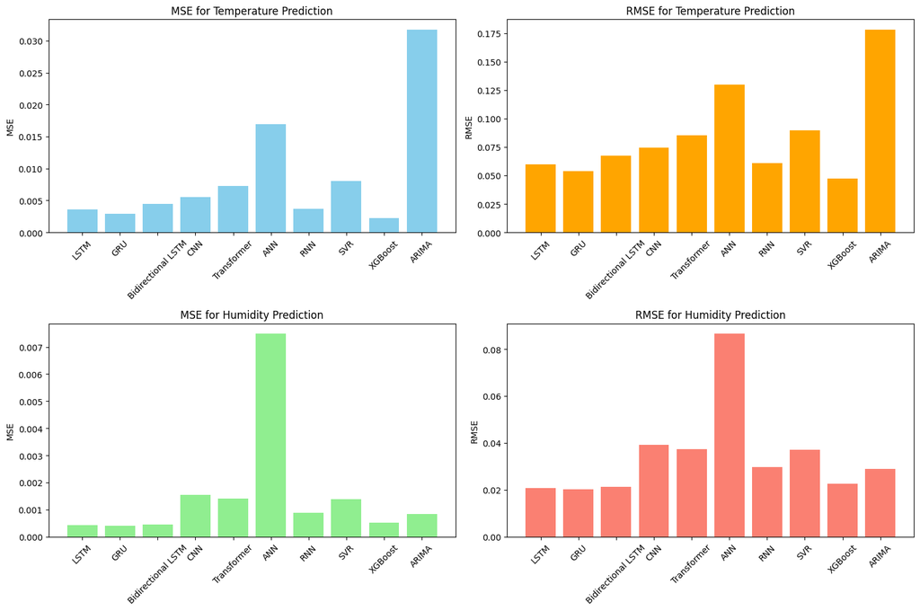

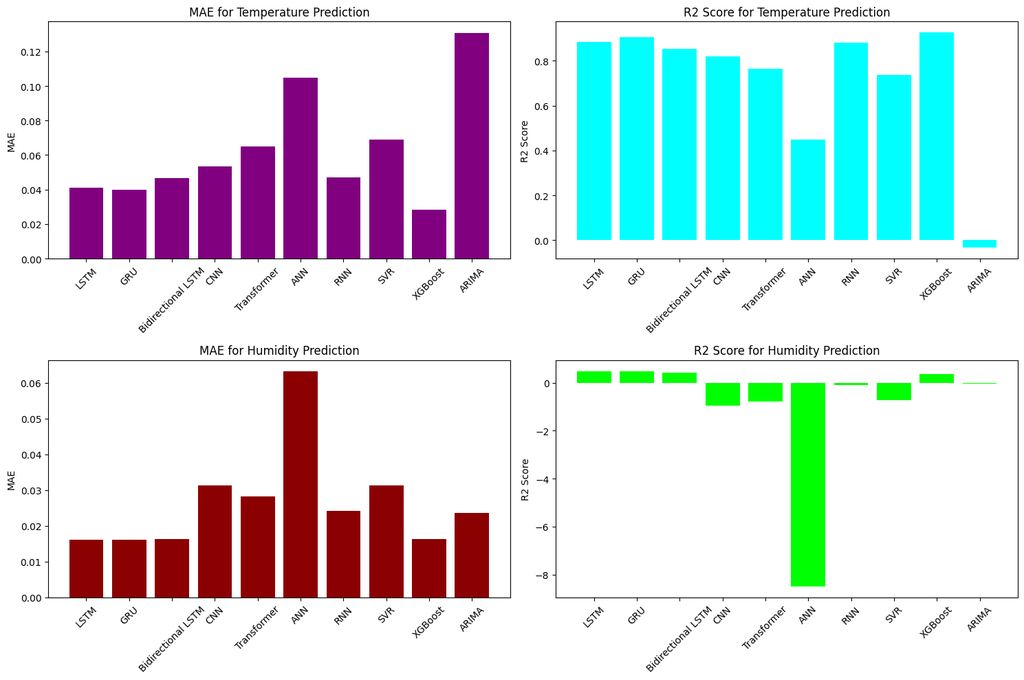

```python
# Additional Graphs for Model Comparison

# Collect metrics for each model
model_metrics = {
    'Model': [],
    'MSE (Temp)': [],
    'RMSE (Temp)': [],
    'MAE (Temp)': [],
    'R2 (Temp)': [],
    'MSE (Humid)': [],
    'RMSE (Humid)': [],
    'MAE (Humid)': [],
    'R2 (Humid)': []
}

# Gather data for plotting
for model_name, (y_test_temp, y_pred_temp, y_test_humid, y_pred_humid) in models.items():
    mse_temp, rmse_temp, mae_temp, r2_temp = calculate_metrics(y_test_temp, y_pred_temp)
    mse_humid, rmse_humid, mae_humid, r2_humid = calculate_metrics(y_test_humid, y_pred_humid)

    model_metrics['Model'].append(model_name)
    model_metrics['MSE (Temp)'].append(mse_temp)
    model_metrics['RMSE (Temp)'].append(rmse_temp)
    model_metrics['MAE (Temp)'].append(mae_temp)
    model_metrics['R2 (Temp)'].append(r2_temp)
    model_metrics['MSE (Humid)'].append(mse_humid)
    model_metrics['RMSE (Humid)'].append(rmse_humid)
    model_metrics['MAE (Humid)'].append(mae_humid)
    model_metrics['R2 (Humid)'].append(r2_humid)

# Convert to DataFrame for easier plotting
metrics_df = pd.DataFrame(model_metrics)

# Plotting the metrics
plt.figure(figsize=(15, 10))

# MSE for Temperature
plt.subplot(2, 2, 1)
plt.bar(metrics_df['Model'], metrics_df['MSE (Temp)'], color='skyblue')
plt.title('MSE for Temperature Prediction')
plt.xticks(rotation=45)
plt.ylabel('MSE')

# RMSE for Temperature
plt.subplot(2, 2, 2)
plt.bar(metrics_df['Model'], metrics_df['RMSE (Temp)'], color='orange')
plt.title('RMSE for Temperature Prediction')
plt.xticks(rotation=45)
plt.ylabel('RMSE')

# MSE for Humidity
plt.subplot(2, 2, 3)
plt.bar(metrics_df['Model'], metrics_df['MSE (Humid)'], color='lightgreen')
plt.title('MSE for Humidity Prediction')
plt.xticks(rotation=45)
plt.ylabel('MSE')

# RMSE for Humidity
plt.subplot(2, 2, 4)
plt.bar(metrics_df['Model'], metrics_df['RMSE (Humid)'], color='salmon')
plt.title('RMSE for Humidity Prediction')
plt.xticks(rotation=45)
plt.ylabel('RMSE')

plt.tight_layout()
plt.show()

# Plotting MAE and R2 for further comparison
plt.figure(figsize=(15, 10))

# MAE for Temperature
plt.subplot(2, 2, 1)
plt.bar(metrics_df['Model'], metrics_df['MAE (Temp)'], color='purple')
plt.title('MAE for Temperature Prediction')
plt.xticks(rotation=45)
plt.ylabel('MAE')

# R2 Score for Temperature
plt.subplot(2, 2, 2)
plt.bar(metrics_df['Model'], metrics_df['R2 (Temp)'], color='cyan')
plt.title('R2 Score for Temperature Prediction')
plt.xticks(rotation=45)
plt.ylabel('R2 Score')

# MAE for Humidity
plt.subplot(2, 2, 3)
plt.bar(metrics_df['Model'], metrics_df['MAE (Humid)'], color='darkred')
plt.title('MAE for Humidity Prediction')
plt.xticks(rotation=45)
plt.ylabel('MAE')

# R2 Score for Humidity
plt.subplot(2, 2, 4)
plt.bar(metrics_df['Model'], metrics_df['R2 (Humid)'], color='lime')
plt.title('R2 Score for Humidity Prediction')
plt.xticks(rotation=45)
plt.ylabel('R2 Score')

plt.tight_layout()
plt.show()
```

**LSTM (Long Short-Term Memory):** Temperature: This model does a good job predicting temperature, with low average errors and a high score indicating it explains most of the variability in the data. Humidity: It also performs well with small average errors, but it doesn’t explain humidity data as effectively as temperature.

**GRU (Gated Recurrent Unit):** Temperature: GRU is even better at predicting temperature than LSTM, with slightly lower errors and a higher score indicating better performance. Humidity: It’s similar to LSTM in terms of average errors but explains humidity data a bit better.

**Bidirectional LSTM:** Temperature: This model’s temperature predictions are less accurate than LSTM, with higher errors and a lower performance score. Humidity: It performs similarly to LSTM in terms of errors, but the score is lower, meaning it explains less of the variability in humidity data.

**Transformer:** Temperature: Transformers have higher errors and a lower score for temperature, indicating they’re less effective. Humidity: They also perform poorly for humidity with higher errors and a negative score, suggesting they’re not suitable.

**XGBoost:** Temperature: XGBoost performs very well for temperature with the lowest errors and the highest score, making it the best for this task. Humidity: It also does well for humidity with low errors, but its performance score is lower than LSTM for this task.

**ARIMA (AutoRegressive Integrated Moving Average):** Temperature: ARIMA performs the worst for temperature with the highest errors and a very low score. Humidity: It performs reasonably well for humidity, with low errors but a lower score.

**Why Choose LSTM:**

Temperature: LSTM is a strong performer, but GRU and XGBoost are slightly better for temperature prediction. However, LSTM is still a robust choice, especially if you need a model with long-term memory capabilities.

Humidity: LSTM performs well with low errors, though GRU is a bit better. The LSTM model strikes a good balance between accuracy and performance for humidity.

**Reasons to Choose LSTM:**

1. Balanced Performance: LSTM provides a good balance between accuracy and explaining variance for temperature, which is crucial if both temperature and humidity predictions are important.
2. Consistency: LSTM offers stable performance across different types of data (temperature and humidity), which can be beneficial in a real-world scenario where consistency is key.
3. Long-Term Dependencies: LSTM’s strength is in capturing long-term dependencies and sequential data patterns, which can be advantageous if your data has temporal aspects or requires understanding patterns over time.
4. Versatility: LSTM is more versatile and can handle various types of sequential data, making it a reliable choice if your data involves time series or sequential dependencies.